# How Did the Stock Market Perceive Presidential Lobbying Restrictions?

Huchen Liu & Nhat-Dang Do

June 13, 2017

In this study, we ask how the stock market perceived lobbying restrictions imposed by two freshly sworn-in U.S. presidents, Barack Obama and Donald Trump. Both presidents issued executive orders at the outset of their terms restricting the lobbying activity of so-called “revolving-door lobbyists” dealing with the executive branch.[^1] We use stock prices to guage whether investors perceived these orders as credible, and find weak evidence that they perceived both orders as credible.

The fundamental premise upon which we look to the stock market for the impact of the presidential lobbying restrictions is that changes in stock prices should reflect investors’ perceptions of how current events influence the financial position of companies. If they perceived the orders as credible, the companies purportedly targeted by the orders should have experienced an immediate decrease in their value in the stock market relative to other companies. By intention, the orders targeted companies that used revolving-door lobbyists to lobby the executive branch. Using a difference-in-differences approach and a large sample of publicly traded companies, we examine whether these targeted companies fared more poorly after the orders were issued compared to other companies.

The following diagram classifies companies by their lobbying activity relevant to our conceptualization of the treatment assignment. Our entire sample of companies consists of all those on the three major U.S. stock exchanges (AMEX, NASDAQ, and NYSE), and our determination of companies’ lobbying activity is based on their reported lobbying activity in the year before the presidents took office (2008 for the Obama analysis and 2016 for the Trump analysis). Stock price data were downloaded in bulk from Google Finance.[^2] Data on companies’ lobbying activity come from manually processing information from the lobbying disclosure database downloadable in bulk from the website of Congress.[^3] The numbers in the diagram denote the number of companies in each category, and show that the vast majority of companies did not lobby at all (the lightest shade). Of the small portion that lobbied, most of them did not engage in lobbying activity subject to the regulation of the executive orders (the medium shade) - i.e., they did not use revolving-door lobbyists to lobby the executive branch.

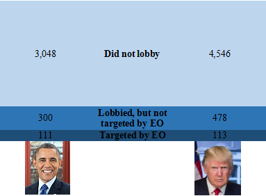

EOs as Treatment

Those companies whose lobbying activity was subject to the executive orders made up a small fraction of all companies in our sample (the darkest shade). These make up the treatment group. The control group is either all companies not targeted by the executive orders (the lightest shade plus the medium shade) or all other lobbying companies (the medium shade only). I will explain the rationale for the two control groups when presenting analysis. The following table stylistically summarizes the quantities of interest in our difference-in-differences framework, applicable to either control group. In this framework, the treatment effect (average treatment effect on the treated) is $\tau = (Y_{1, 1} - Y_{1, 0}) - (Y_{0, 1} - Y_{0, 0})$.

Quantities of Interest in Difference-in-Differences Design

| **Condition** | **Before** | **After** |
| --- | --- | --- |
| Treatment | $Y_{1, 0}$ | $Y_{1, 1}$ |
| Control | $Y_{0, 0}$ | $Y_{0, 1}$ |

We now present difference-in-differences analysis estimating the treatment effect of the executive orders in two analogous sets of figures and regressions, beginning with the Obama order. We first compare the stock prices of treated companies with those of untreated companie (including those that did not lobby at all), before and after the issuance of the order. The following figure displays the two groups’ price trends starting from five days before the issuance and ending on the day after. This plot is not very informative, however. The assumption of parallel trends undergirding the difference-in-differences method clearly does not hold, and the mean stock price of treated companies was very low compared to that of untreated companies. These facts were driven by one one company in the control group that had a very high stock price that changed erratically. To address this issue, we conduct nearest-distance matching on the data, finding one match for each company in the treatment group using the companies’ starting stock price.

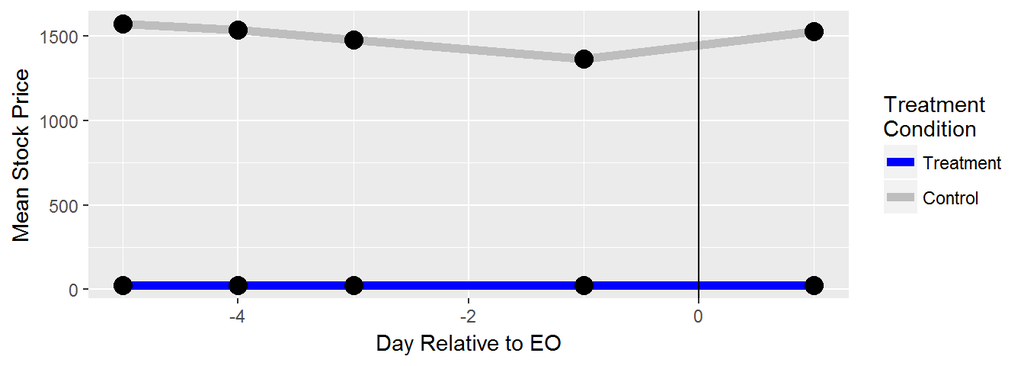

Targeted Companies (111) vs. All Other companies (3,348), Obama

Using pre-matched data, we plot the price trends again, shown below. The trends now appear basically parallel. In fact, they appear largely parallel both before and after the trend, suggesting that the executive order did not have much of a differential effect on treated companies relative to untreated companies. A first-difference regression equation, regressing companies’ stock price changes before and after the issuance of the order on their treatment status, results displayed after the figure, confirms that the order’s treatment effect was statistically indistinguishable from zero.

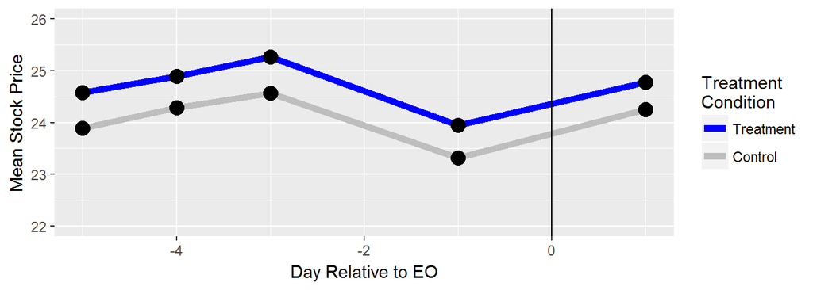

Targeted Companies (111) vs. All Other Companies (111) (Matched Sample), Obama

```
##
## Call:
## lm(formula = change ~ treat, data = m3.d.data.BO)
##
## Residuals:
##     Min      1Q  Median      3Q     Max
## -2.2464 -0.6372 -0.2819  0.3836  4.9125
##
## Coefficients:
##             Estimate Std. Error t value Pr(>|t|)
## (Intercept)  0.93748    0.09927   9.444   <2e-16 ***
## treat       -0.11108    0.14039  -0.791     0.43
## ---
## Signif. codes:  0 '***' 0.001 '**' 0.01 '*' 0.05 '.' 0.1 ' ' 1
##
## Residual standard error: 1.046 on 220 degrees of freedom
## Multiple R-squared:  0.002838,   Adjusted R-squared:  -0.001695
## F-statistic: 0.6261 on 1 and 220 DF,  p-value: 0.4297
```

However, it may not make much theoretical sense to compare treated companies with all other companies regardless of whether they lobbied. We proceed to compare the stock prices of treated companies with those not targeted by the executive order but nevertheless engaged in lobbying in 2008. The price trends displayed below suggest that the order seemed to cause a smaller price increase on average for treated companies compared to untreated lobbying companies. A first-difference regression, however, shows that this average difference was statistically insignificant. Our confidence in this null finding, however, is dampened by the observed fact that pre-treatment trends were not quite parallel for the two groups. To address this issue, and to help rescue any treatment effect that may actually exist but has gone unnoticed, we again rely on nearest-distance matching, this time on the restricted sample of companies.

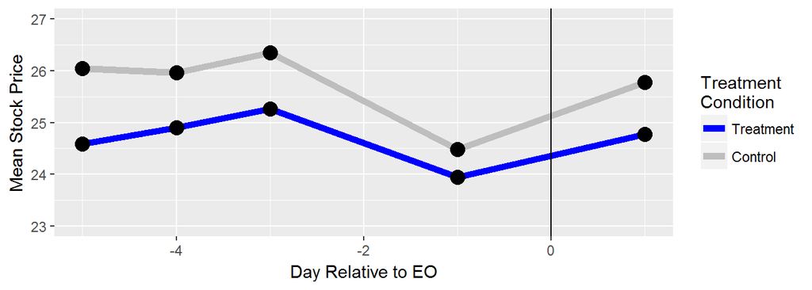

Targeted Companies (111) vs. Non-Targeted Lobbying Companies (300), Obama

```
##
## Call:
## lm(formula = change ~ treat, data = subset(d.data.BO, treat1 ==
##     1))
##
## Residuals:
##     Min      1Q  Median      3Q     Max
## -12.822  -0.962  -0.526   0.034 116.188
##
## Coefficients:
##             Estimate Std. Error t value Pr(>|t|)
## (Intercept)   1.3017     0.3449   3.774 0.000184 ***
## treat        -0.4753     0.6637  -0.716 0.474283
## ---
## Signif. codes:  0 '***' 0.001 '**' 0.01 '*' 0.05 '.' 0.1 ' ' 1
##
## Residual standard error: 5.974 on 409 degrees of freedom
## Multiple R-squared:  0.001253,   Adjusted R-squared:  -0.001189
## F-statistic: 0.5129 on 1 and 409 DF,  p-value: 0.4743
```

We now present trends generated using this matched data, which again a negative average treatment effect of the executive order. The corresponding first-difference regression, however, again yields a treatment effect that falls short of significance, though it has a much smaller p-value this time, approaching marginal statistical significance.

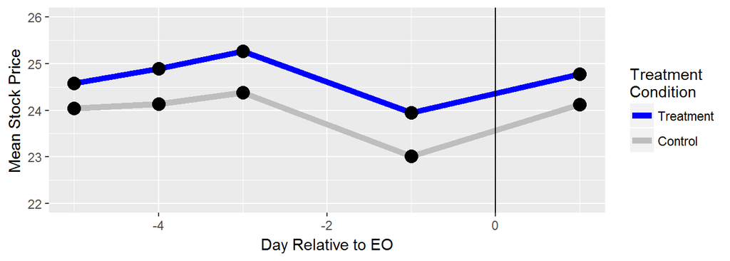

Targeted Companies (111) vs. Non-Targeted Lobbying Companies (111) (Matched Sample), Obama

```
##
## Call:
## lm(formula = change ~ treat, data = m3.d.data.sub.BO)
##
## Residuals:
##     Min      1Q  Median      3Q     Max
## -3.7015 -0.7015 -0.3614  0.2360  7.5885
##
## Coefficients:
##             Estimate Std. Error t value Pr(>|t|)
## (Intercept)   1.1115     0.1302   8.539 2.25e-15 ***
## treat        -0.2851     0.1841  -1.549    0.123
## ---
## Signif. codes:  0 '***' 0.001 '**' 0.01 '*' 0.05 '.' 0.1 ' ' 1
##
## Residual standard error: 1.372 on 220 degrees of freedom
## Multiple R-squared:  0.01079,    Adjusted R-squared:  0.00629
## F-statistic: 2.399 on 1 and 220 DF,  p-value: 0.1229
```

Entirely analogous analysis conducted on the Trump-era data also turns up weak but suggestive evidence that the executive order had a different impact on targeted companies compared to others. Having presented the Obama analysis, we think the Trump figures and regression results should be self-explanatory. The Trump results may indicate that the Trump order was perceived as more credible than its Obama counterpart: Its treatment effect in one particular model reaches conventional levels of significance (p-value = 0.040). However, we doubt that this meaningfully alters the big picture. Analyzing stock prices turns up weak evidence at best for the two executive orders’ perceived credibility.

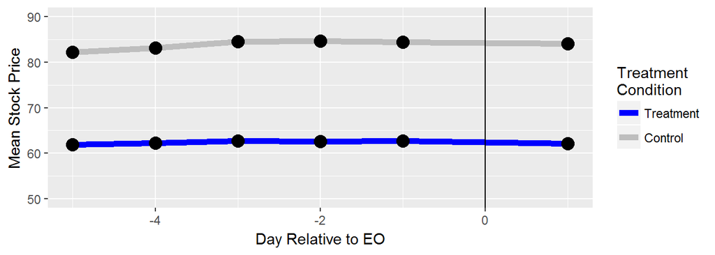

Targeted Companies (113) vs. All Other Companies (5,024), Trump

```
##
## Call:
## lm(formula = change ~ treat, data = d.data.DT)
##
## Residuals:
##     Min      1Q  Median      3Q     Max
## -499.60   -0.06    0.26    0.38   17.21
##
## Coefficients:
##             Estimate Std. Error t value Pr(>|t|)
## (Intercept) -0.38059    0.09932  -3.832 0.000129 ***
## treat       -0.21180    0.66920  -0.316 0.751639
## ---
## Signif. codes:  0 '***' 0.001 '**' 0.01 '*' 0.05 '.' 0.1 ' ' 1
##
## Residual standard error: 7.035 on 5128 degrees of freedom
##   (7 observations deleted due to missingness)
## Multiple R-squared:  1.953e-05,  Adjusted R-squared:  -0.0001755
## F-statistic: 0.1002 on 1 and 5128 DF,  p-value: 0.7516
```

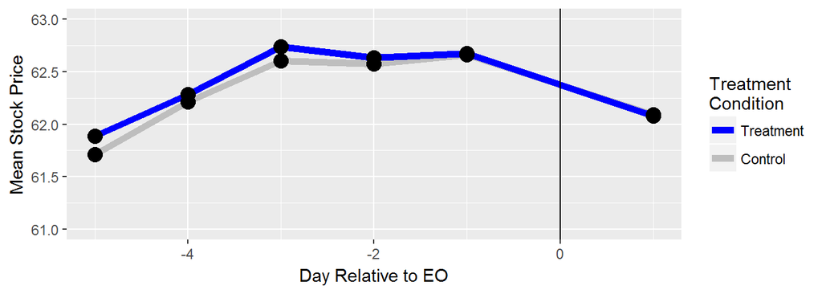

Targeted Companies (113) vs. All Other Companies (113) (Matched Sample), Trump

```
##
## Call:
## lm(formula = change ~ treat, data = m3.d.data.DT)
##
## Residuals:
##      Min       1Q   Median       3Q      Max
## -10.5276  -0.1951   0.2179   0.5506   2.5724
##
## Coefficients:
##             Estimate Std. Error t value Pr(>|t|)
## (Intercept) -0.57336    0.10571  -5.424 1.51e-07 ***
## treat       -0.01903    0.14949  -0.127    0.899
## ---
## Signif. codes:  0 '***' 0.001 '**' 0.01 '*' 0.05 '.' 0.1 ' ' 1
##
## Residual standard error: 1.124 on 224 degrees of freedom
## Multiple R-squared:  7.231e-05,  Adjusted R-squared:  -0.004392
## F-statistic: 0.0162 on 1 and 224 DF,  p-value: 0.8988
```

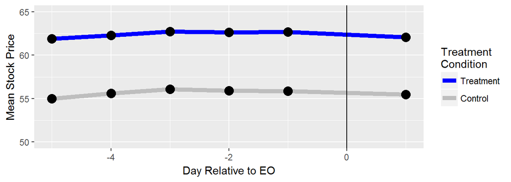

Targeted Companies (113) vs. Non-Targeted Lobbying Companies (478), Trump

```
##
## Call:
## lm(formula = change ~ treat, data = subset(d.data.DT, treat1 ==
##     1))
##
## Residuals:
##      Min       1Q   Median       3Q      Max
## -10.5276  -0.2349   0.1551   0.3751   7.2551
##
## Coefficients:
##             Estimate Std. Error t value Pr(>|t|)
## (Intercept) -0.38510    0.04401  -8.750   <2e-16 ***
## treat       -0.20728    0.10066  -2.059   0.0399 *
## ---
## Signif. codes:  0 '***' 0.001 '**' 0.01 '*' 0.05 '.' 0.1 ' ' 1
##
## Residual standard error: 0.9623 on 589 degrees of freedom
## Multiple R-squared:  0.007148,   Adjusted R-squared:  0.005463
## F-statistic: 4.241 on 1 and 589 DF,  p-value: 0.03991
```

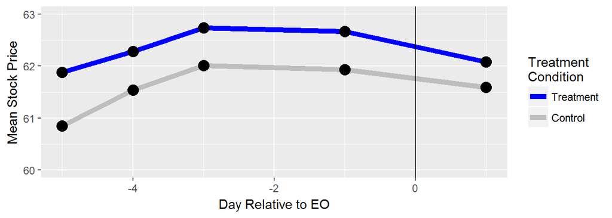

Targeted Companies (113) vs. Non-Targeted Lobbying Companies (113) (Matched Sample), Trump

```
##
## Call:
## lm(formula = change ~ treat, data = m3.d.data.sub.DT)
##
## Residuals:
##      Min       1Q   Median       3Q      Max
## -10.5276  -0.2178   0.1497   0.4199   7.2097
##
## Coefficients:
##             Estimate Std. Error t value Pr(>|t|)
## (Intercept)  -0.3397     0.1083  -3.137  0.00194 **
## treat        -0.2527     0.1532  -1.649  0.10047
## ---
## Signif. codes:  0 '***' 0.001 '**' 0.01 '*' 0.05 '.' 0.1 ' ' 1
##
## Residual standard error: 1.151 on 224 degrees of freedom
## Multiple R-squared:  0.012,  Adjusted R-squared:  0.007589
## F-statistic: 2.721 on 1 and 224 DF,  p-value: 0.1005
```

[^1]: Pres. Obama’s executive order, “Ethics Commitments by Executive Branch Personnel,” was issued on January 21, 2009. It banned lobbyists entering his administration from working on matters they previously lobbied on or working in agencies they previously lobbied for two years, and banned those who would leave posts in his administration from lobbying the administration until Obama left office. Pres. Trump’s executive order, “Ethics Commitments by Executive Branch Appointees,” was issued on January 28, 2017. It banned executive branch officials from lobbying the administration for five years after they left and banned them from lobbying on behalf of foreign governments for life.
[^2]: http://www.google.co.uk/finance.
[^3]: http://disclosures.house.gov/ld/ldsearch.aspx.